# Depth Analysis in Native Space

## Analytical strategy

**Quantifying brain activity in each cortical depth bin**  
We are interested in detecting differences in the profile of layer-specific activity during the observation of either scrambled or unscrambled movies representing goal-directed actions.

By profile of activity we mean the brain activity - estimated using GLM - at different cortical depth (bin). The basic unit of estimation is therefore the activity at a given cortical depth bin.

**Unreliability of a common anatomical template (e.g. MNI)**  
Estimating this quantity at the group level using a template proved unfeasible at the least, since moderate degrees-of-freedom elastic transformation do not - and should not - perfectly align the morphology of every subject, while aggressive transformation disrupt the single-subject morphology.

In addition, voxel-level functional localization is already hard to establish for conventional spatial resolution fMRI (2-3mm), and it is therefore practically unfeasible for layer-specific fMRI (~0.6 mm resolution).

**Group analysis based on Juelich regions**  
This prompted me to devise a different strategy to estimate group-level effects *without* relying on a common anatomical template. This strategy is based on two insights:

- carrying out layer-specific estimation in the native space is the best strategy to preserve layer-specific information, which would be lost in interpolations to other-subject spaces, and likely compromised in the transformation to the anatomical scan - as it would require upsampling.
- activity can be quantified at the level of atlas-based cytoarchitectonically defined maps, for which the degree of precision in template-to-subject registration needs not to be extremely precise

In this notebook, I estimate layer-specific activity for each subject, condition, run, in each of the cytoarchitectonically defined regions in the Juelich atlas. The basic data which needs to be available is therefore, for each subject:

- thresholded Z stat for each contrast and each run in the native space
- cortical depth map for each run registered in the native space
- Juelich maps for each run registered in the native space

**Quantifying the proportion of suprathreshold voxels across layers instead of Z value**  
In a previous analysis I considered, for each cortical depth bin in each Juelich region, the average Z value across runs for each subject in either contrasts (Motion and Scrambled), and took this quantity to the group level.

The choice of using the thresholded zstat instead of the raw zstat is twofold:

- thresholded zstat are already present on the map of cortical depth only (rather than in the entire brain - or partial brain FOV), which is where I want to estimate my statistic
- thresholded zstat have already been corrected for MCP at the subject level

While these properties still justify the use of thresholded Z values at the single run level in the native space to *select* the voxels to consider, I then realized that the *mean thresholded Z value across runs* might not be the best quantity for our purposes.

The Z value reflecting the significant activity *in each contrast* is actually a binary (significant or not) rather than a continous estimator. For using the thresholded Z value in order to assess difference one could maybe consider the Z value resulting from the contrast of Motion vs. Scrambled. However the latter led to poor results and mostly scattered small clusters of nonsignificant voxels: it looks like the two contrasts activate mostly the same regions, and this comparison does not have the appropriate granularity to highlight layer-based differences.

I then thought to use the count of voxels in each bin, but also this quantity is not a good one, since (1) it relies on a same Z threshold which can lead to different number of voxels for each contrast and - especially - (2) it does not consider the single bin in relation to the entire cortical depth profile.

Finally I resolved to use a metric which appear not to have the limitations above, that is, for each contrast, **the proportion of above Z threshold voxels in each bin with respect to that in other bins**.

This metric has the advantages of:

1. being independent from the absolute (thresholded) values of Z voxels across contrasts
2. being independent from the absolute number of voxels in each bin/region for each contrast
3. relating the effect within each bin to the effect in all the other bins

Therefore in the present analysis the metric that will be taken to the group level for each subject, juelich ROI and bin is the average proportion of suprathreshold voxels across runs.

**User-defined criteria**  
These choices require the user to input some thresholding criteria:

- It might be the case - as it actually is - that not for every subject the two contrasts yield significant clusters of voxels in each run.
- Even so, the number of voxels in a given ROI might still be very small to be considered interesting: keep in mind that we are looking at proportions: a ROI with only one voxel in a given ROI would give a very distorted view of the proportion of active voxels across the whole cortical depth.
- Even if both of the above conditions are satisfied, it might be so only in 2-3 subjects, which would make the statistical inference on the comparison between the two contrasts completely invalid.

For these reasons, I have to input the following thresholding parameters manually and in this order:

1. for a given subject, the minimum amount of voxels in each Julich ROI (note that the results have already been corrected with GRF, therefore they can be assimilated to clusters)
2. for a given subject, the minimum amount of runs in which a given ROI featured suprathreshold voxels
3. at the group level, minimum amount of subjects having suprathreshold voxels in each ROI

In the present notebook, these criteria must be input below in the cell `Run for all subjects and all contrasts`. Just before the table and plot of the results, there is a summary of the parameters used.

These criteria are indeed quite stringent, since they are based on the single-subject and single-run corrected results. However I believe that this can result in a more robust result.

Note: I did not develop an interactive version of this machine since for every variation of a parameter, it needs to process about 300 high-resolution nifti images, which takes about 20 seconds.

**Analytic complexity** (i.e. why this pipeline is so long)  
The engineering of the method is quite complex, since I have:

- 2 conditions for each run
- 8 runs for each subject
- N Juelich ROIs for each subject/run
- 8 cortical depth maps for each subject (one for each run)

A (simplified) overview of the complexity of the data is provided in the interactive tree map below.

**Notation**: D = Depth, JU = Juelich atlas/region, Z = Z-statistic image from the GLM

A copy of this document in pdf format can be created with

```
rmarkdown::render("depth_native_analysis_V[version_numba].Rmd", 'pdf_document')
```

Make sure to comment the part relative to the creation of the interactive collapsibletree.

## Select sub and Zcontrast, and choose thresholds and number of D bins

The values defined here for `SUBID`, `Zcontrast`, `zthr`, `clusterSizeThr`, `nbin` and `thr_N_taskruns` are only for development. The actual chosen values can be found below at *Run for all subjects and all contrast* where the main function is run for each subject and contrast.

```r
# User-defined parameters, which will become selector widgets

SUBID = "sub_02"     # df %>% distinct(sub) to see all available sub
Zcontrast <- "thresh_zstat1"
zthr <- 2.3  # use smallcap to indicate that it is a scalar
clusterSizeThr <- 100  # to build a meaningful histogram
nbin <- 10 # set hist breaks to a fixed range
thr_N_taskruns <- 2 # in how many taskruns (>2) should I find sig clusters, to consider it interesting?



# -----------------------------------------------------------------------------

# Immutable parameters
gitdir <- "/data00/layerfMRI/Github_repo/"
bd <- paste0(gitdir,"layerfMRI/analyses/depth_native/")

library(RNifti)
library(stringr)
library(tidyr)
library(dplyr)
library(purrr)
select <- dplyr::select
library(tibble)
library(broom)
library(ggplot2)
library(ggthemes)
library(kableExtra)
library(tictoc)


julabels <- read.csv("labels_juelich.csv") %>%
  mutate(name = str_replace(name,"['-/]","")) %>%    # get rid of special chars
  mutate(numba = index + 1) %>%
  select(-index)
```

## Create dictionary of data from `list.files`

The magic is provided by `tidyr::separate`

```r
create_dizio_files <- function(data_native_dir = "data_native") {

  df <- list.files("data_native", recursive = T) %>% as.data.frame()
  names(df) <- "fname"


  df <- df %>%
    rowwise() %>%
    tidyr::separate(
      fname, c("sub","contrast","taskrun","zstat"),
      sep = "/", fill = "right", remove = FALSE
    ) %>%
    mutate(taskrun = str_extract(taskrun,"task_[1-4]\\_run_[1-2]")) %>%
    mutate(zstat = str_extract(zstat,"thresh_zstat[1-4]")) %>%
    mutate(pathname = paste0(bd,"/data_native/",fname)) %>%
    dplyr::select(-fname)

  return(df)
}



# ------------------------------  Code for Main -------------------------------
# df <- create_dizio_files()

df <- create_dizio_files()
# show df tree
library(collapsibleTree)
dataset <- df %>% dplyr::select(sub,contrast,taskrun,zstat)
collapsibleTree(dataset, c("sub","contrast","taskrun","zstat"), collapsed = T, zoomable = F)
```

[interactive chart not shown]

## Load Z, D, JU and extract values for Z sig voxels within JU ROIs

Load the nii for Zstat[contrast], Depth and JUelich atlas for all 8 taskruns, all in native space:

- Z_nii : 8 for each contrast (Motion, Scrambled, M>S, S>M)
- D_nii : 8, one for each taskrun
- JU_nii : 8, one for each taskrun

Then for each run/contrast

1. threshold the Z_nii to zthr and create a Zthr_idx of suprathreshold voxels
2. extract Z_vals, D_vals and JU_vals at the locations of Zthr_idx
3. purrr Z, D, JU vals into a list of tibbles (8)
4. retain for each taskrun/tibble only the Z and D vals where JU > 0 - i.e. inside JU ROIs

**NB**: the two functions are separate so that I don’t need to reload the niis if I choose another Z threshold

```r
load_niis <- function(SUBID, Zcontrast) {

  # Load the Z_nii for a given contrast (8, one for each taskrun)
  Z_nii <- df %>%
    filter(sub == SUBID, contrast == "Zstat", zstat == Zcontrast) %>%
    select(pathname) %>% sapply(readNifti)

  # Load the D_nii (8 taskrun)
  D_nii <- df %>%
    filter(sub == SUBID, contrast == "depth") %>%
    select(pathname) %>% sapply(readNifti)

  # Load the JU_nii (8 taskrun)
  JU_nii <- df %>%
    filter(sub == SUBID, contrast == "atlas") %>%
    select(pathname) %>% sapply(readNifti)

  niis <- list(Z = Z_nii, D = D_nii, JU = JU_nii)

  return(niis)
}


get_Z_D_JU_vals <- function(zthr, Z_nii, D_nii, JU_nii) {

  # Create an index of sig voxels, i.e. whose value is > zthr
  Zthr_idx <- sapply(Z_nii, function(x) {which(x > zthr)})

  # Extract Z, D, JU values at the location of Zthr_idx
  Z_vals <- mapply( function(vols,idx) vols[idx], Z_nii, Zthr_idx )
  D_vals <- mapply( function(depth,idx) depth[idx], D_nii, Zthr_idx )
  JU_vals <- mapply( function(atlas,idx) atlas[idx], JU_nii, Zthr_idx )

  # Purrr everything into a list of tibbles and retain only D,Z values
  # inside JU ROIs
  vals <- pmap(
    list(Z_vals, D_vals, JU_vals),
    function(Z,D,JU) tibble(Z,D,JU) %>% filter(JU > 0)
  )

  return(vals)
}


# ------------------------------  Code for Main -------------------------------

SUBID = "sub_02"     # df %>% distinct(sub) to see all available sub
Zcontrast <- "thresh_zstat1"
zthr <- 2.3  # use smallcap to indicate that it is a scalar

# Load Z, D, JU and extract values for Z sig voxels within JU ROIs
niis <- load_niis(SUBID, Zcontrast)
vals <- get_Z_D_JU_vals(zthr, niis$Z, niis$D, niis$JU)
```

## Get mean Z, their count for each D bin in each JU region in each taskrun, as well as their proportion across cortical depth layers

Here we use the dataframe `vals` created above - containing each subtibbles, one for each taskrun - to sample the depth in `nbin` bins (e.g. deciles if `nbin` = 10) and then extract the mean suprathreshold Z value for each cortical depth bin. Importantly, we get also the count of suprathreshold voxels and their proportion in each bin wrt to every other bin. This calculation is carried out separately for each taskrun (using `map`), and for each ROI.

Afterwards we create a `taskrun` column - derived from the numba of subtibbles (`length(ALL_taskruns_meanZ)`) - and we row-bind the mean Z for each bin in each ROI across taskrun, for later averaging across taskruns.

Practically, for each taskrun we `map` the following procedure:

1. group the data by JU ROIs, since the analysis is carried out separately for each one of them
2. count the numba of sig voxels in each JU ROI, to be able to exclude ROIs with numba voxels < clusterSizeThr
3. remove ROIs with numba voxels < clusterSizeThr
4. split the subtibble in many tibbles, each one for one JU ROI
5. create a factor indexing the voxels in each cortical depth bin, e.g. [>0..0.1], [0.11..0.2] … [0.91..1]
6. group all the values (Z,D) by the bin they belong to
7. calculate mean Z in each D bin
8. calculate the proportion of activated voxels in each bin wrt to all other bins. **This is our desired metric of interest**. The final tibble of each ROI has N rows - one for each bin - and two columns for prop_Z and JU name.
9. bind all the ROI-specific tibbles by rows. Therefore in the final tibble there will be N JU_ROIs * 10 rows

**NB**: in a previous version there was a mistake due to the fact that I extracted the voxels (and relative Z value) for each bin with `dplyr::ntile`, while `base::findInterval` should be used:

- CORRECT : `map(~ .x %>% mutate(D_bins = findInterval(D, seq(0, 1, by=1/nbin))) %>% arrange(D_bins) )`
- WRONG : `map(~ .x %>% mutate(D_bins = ntile(D, nbin) %>% as.factor) %>% arrange(D) )`

`ntile` actually builds N ranks (where N = nbin), however this means that if e.g. there are many more voxels in depth = 0..0.1, these voxels will occupy not only the first bin, but several ranks. Instead here I only want to extract voxels at different levels of depth, considering that their distribution along the cortical depth can be highly skewed. Therefore the funciton `base::findInterval` should be used.

As a matter of fact, the main group-level results do not change much using either function.

```r
get_meanZ <- function(vals, clusterSizeThr, nbin) {

  ALL_taskruns_meanZ <- vals %>%
    group_by(JU) %>%                    # 1. group_by JU ROI
    mutate(nvox = n()) %>%              # 2. count numba vox in each JU ROI
    arrange(nvox, JU) %>%               # sort by ascending nvox, just to check
    filter(nvox > clusterSizeThr) %>%   # 3. remove JU with nvox < clusterSizeThr
    group_split() %>%                   # 4. split: one for each JU ROI
    map(~ .x %>% mutate(D_bins = findInterval(D, seq(0, 1, by=1/nbin))) %>% arrange(D_bins) ) %>%  #
    map(~ .x %>% group_by(D_bins) ) %>% # 6. group values by bin
    map(~ .x %>% summarise(             # 7. calculate mean Z for each bin of D
      mean_Z = mean(Z),
      # sd_Z = sd(Z),
      numba_Z = n(),
      JU = mean(JU),
      .groups = "drop"
    )) %>%
    map(~ .x %>% mutate(prop_Z = numba_Z/sum(numba_Z)) ) %>%  # 8. create a column with the proportion
    bind_rows()                         # 9. put the summary of all the JU ROIs

  return(ALL_taskruns_meanZ)
}


# # To test the function and plot the results for one taskrun only:
# ALL_taskruns_meanZ <- map(list(vals[[1]]), ~ get_meanZ(.x, clusterSizeThr, nbin))
#
# ALL_taskruns_meanZ %>% as.data.frame() %>%
#   ggplot( aes(x = as.numeric(D_bins), y = mean_Z, fill = as.numeric(D_bins)) ) +
#   geom_bar(stat = "identity", width = 1) +
#   coord_cartesian(ylim = c(1.9, zthr + 2)) +
#   facet_wrap(~ JU, scales = "free")


# ------------------------------  Code for Main -------------------------------

clusterSizeThr <- 100  # to build a meaningful histogram
nbin <- 10 # set hist breaks to a fixed range

# Get mean Z for each D bin in each JU region in each taskrun
# 1. extract the metric of interest for each taskrun (madonna!)
ALL_taskruns_meanZ <- map(vals, ~ get_meanZ(.x, clusterSizeThr, nbin) )


# 2. assign a taskrun column - for further averaging - and bind_rows all together
ALL_taskruns_meanZ <- pmap(
  list(1:length(ALL_taskruns_meanZ), ALL_taskruns_meanZ),
  function(nth_taskrun, df_taskrun) df_taskrun %>% mutate(taskrun = nth_taskrun)
) %>% bind_rows()
```

## Average the proportion of suprathreshold Z voxels (across D bins) across taskruns

1. Before averaging, include only ROIs where sig clusters where found in an acceptable numba of runs (thr_N_taskruns)
2. Split the tibble in N tibbles, where N is the numba of JU ROI with sig clusters in at least n_aboveThr_taskrun
3. For each ROI (map) group the prop_Z values by bin, so that you will be able to estimate the average prop_Z for each Depth bin across taskruns
4. Calculate the mean of prop_Z across taskruns. **This is the quantity that will be taken to the group-level analysis**
5. Finally, bind the results for all ROIs in a single tibble

```r
get_MEAN_taskruns_meanZ <- function(ALL_taskruns_meanZ, thr_N_taskruns) {

  MEAN_taskruns_meanZ <- ALL_taskruns_meanZ %>%
    group_by(JU) %>%                       # again, everything is JU ROI-specific
    mutate(n_aboveThr_taskrun = n_distinct(taskrun)) %>%
    filter(n_aboveThr_taskrun >= thr_N_taskruns) %>%   # 1. filter ROI < n_aboveThr_taskrun
    group_split() %>%                      # 2. split ROIs
    map(~ .x %>% group_by(D_bins) ) %>%    # 3. group by D bin across taskruns for each ROI
    map(~ .x %>% summarise(                # 4. get the mean_Z for each D
      TR_mean_Z = mean(prop_Z),    # numba_Z = count; prop_Z = proportion - in case you want to try
      # sd_Z = sd(mean_Z),
      JU = mean(JU),
      .groups = "drop"
    )) %>% bind_rows()

  return(MEAN_taskruns_meanZ)

}

# # Test plotting the result for one subject and one contrast:
# MEAN_taskruns_meanZ %>%
#   ggplot( aes(x = as.numeric(D_bins), y = TR_mean_Z, fill = as.numeric(D_bins)) ) +
#   geom_bar(stat = "identity", width = 1) +
#   geom_linerange( aes(ymin = TR_mean_Z - sd_Z, ymax = TR_mean_Z + sd_Z) ) +
#   coord_cartesian(ylim = c(zthr - 1, zthr + 2)) +
#   facet_wrap(~ JU, scales = "free")

# ------------------------------  Code for Main -------------------------------

thr_N_taskruns <- 4 # in how many taskruns (must be >= 2) should I find sig clusters, to consider it interesting?

# Average the mean Z in each D bin across taskruns
MEAN_taskruns_meanZ <- get_MEAN_taskruns_meanZ(ALL_taskruns_meanZ, thr_N_taskruns)
```

## Main function(s) to get the results in each subject

In this section we group the functions defined above into one main function which is run for each subject : `get_joined_res`.

```
get_joined_res
  └─ get_res_contrast
      ├─ load_niis
      ├─ get_Z_D_JU_vals
      ├─ map(vals, get_meanZ)
      └─ get_MEAN_taskruns_meanZ
```

### (1) Define fn to get the results for each contrast

The `get_res_contrast` returns a dataframe with columns for `[D_bin, TR_mean_Z, JU]` for one subject and **one contrast** (see the resulting `MEAN_taskruns_meanZ` in the previous chunk for an example).

```r
get_res_contrast <- function(SUBID, Zcontrast, zthr, clusterSizeThr, nbin, thr_N_taskruns) {

  # 1. Load Z, D, JU and extract values for Z sig voxels within JU ROIs
  niis <- load_niis(SUBID, Zcontrast)
  vals <- get_Z_D_JU_vals(zthr, niis$Z, niis$D, niis$JU)

  # Get mean Z for each D bin in each JU region in each taskrun
  # 1. extract the metric of interest for each taskrun (madonna!)
  ALL_taskruns_meanZ <- map(vals, ~ get_meanZ(.x, clusterSizeThr, nbin))

  # 2. assign a taskrun column - for further averaging - and bind_rows all together
  ALL_taskruns_meanZ <- pmap(
    list(1:length(ALL_taskruns_meanZ), ALL_taskruns_meanZ),
    function(nth_taskrun, df_taskrun) df_taskrun %>% mutate(taskrun = nth_taskrun)
  ) %>% bind_rows()

  # 3. Average the mean Z in each D bin across taskruns
  MEAN_taskruns_meanZ <- get_MEAN_taskruns_meanZ(ALL_taskruns_meanZ, thr_N_taskruns)

  return(MEAN_taskruns_meanZ)
}

# ------------------------------  Code for NEXT CHUNK ------------------------

# totest <- get_res_contrast(SUBID, Zcontrast, zthr, clusterSizeThr, nbin, thr_N_taskruns)
```

### (2) Define fn to get the result for both contrasts and join them in one dataframe

Calculate the resulting dataframe `[D_bin, TR_mean_Z, JU]` - see cell above - for one subject in **both contrasts**, then `full_join` between contrasts.

Now the subject-specific dataframe is ready for group-level analysis.

```r
get_joined_res <- function(contrast_list, SUBID, Zcontrast, zthr,
                           clusterSizeThr, nbin, thr_N_taskruns) {
  # calculate meanZ for each bin in each ROI -> output separate df for M and S
  res_onesub <- map(
    contrast_list,
    ~ get_res_contrast(SUBID, .x, zthr, clusterSizeThr, nbin, thr_N_taskruns)
  )

  # join tables between contrasts: I use full join since this is the value that will be
  # taken to the group level, even if there are no Zmean for one of the two contrasts
  joined_res <- res_onesub %>%
    reduce(~ full_join(.x, .y, by=c("D_bins","JU")) )

  # rename the meanZ columns with contrast names, and rearrange column order
  joined_res_named <- joined_res %>%
    rename_with(~ names(contrast_list), c("TR_mean_Z.x","TR_mean_Z.y")) %>%
    relocate(JU, .after = D_bins)

  return(joined_res_named)

}


# ------------------------------  Code for Group-level ------------------------

contrast_list <- list(
  Motion = "thresh_zstat1",
  Scrambled = "thresh_zstat2"
)

sub_join_res <- get_joined_res(contrast_list, SUBID, Zcontrast, zthr,
                               clusterSizeThr, nbin, thr_N_taskruns)
```

## Run for all subjects and all contrasts

The user must provide 4 parameters: `zthr, clusterSizeThr, nbin, thr_N_taskruns` (unfold code to see the description).

It returns a dataframe `all` containing the estimate for each subject, which will be used for the Group-level analysis.

**NB**: for high values of `clusterSizeThr` and `thr_N_taskruns` the calculation might break (it would take too much time to build control structures), meaning that for certain subjects, at those thresholds there are no JU ROIs with sig clusters in either contrast.

```r
# ----------------------  User-defined parameters  ----------------------------

zthr <- 2.3            # values already corrected for MCP with GRF (p = 0.05)
clusterSizeThr <- 50   # to build a meaningful histogram
nbin <- 10             # bins to sample the cortical Depth
thr_N_taskruns <- 2    # in how many runs there should be sig clusters, to be interesting?

# ----------------------  End of User-defined parameters  ---------------------


listsub <- df$sub %>% unique()

contrast_list <- list(
  Motion = "thresh_zstat1",
  Scrambled = "thresh_zstat2"
)


tic()

all <- listsub %>%
  map( function(sub) get_joined_res(contrast_list,
                        sub,
                        Zcontrast,
                        zthr,
                        clusterSizeThr,
                        nbin,
                        thr_N_taskruns)) %>% bind_rows()

toc()
```

```
## 20.692 sec elapsed
```

## Group-level analysis

A final parameter that the user should provide is the minimum number of subjects to consider for group-level analysis (`thr_N_subs`). This is due to the fact that there are only 9 subjects. It can happen that only two subjects have sig clusters in a given ROI, which means that the ttest would be run only on two values, which is of course meaningless.

The mean Z values for every JU ROI containing sig clusters are compared between contrasts using a paired t test. The resulting tibble `ttest_res` contains inferential statistics (e.g. T, p) which will be later used for plotting.

Note that the final tibble `ttest_res` can also be unnested to get back the values which went into the ttest. This is useful to plot e.g. bars of the mean Z for each ROI in either contrasts.

```r
# ----------------------  User-defined parameters  ----------------------------

thr_N_subs <- 7

# ----------------------  End of User-defined parameters  ---------------------

# Threshold for minimum numba of subjects and nest the dataframes corresponding
# to each D_bin in each JU ROI
all_nest <- all %>%
  group_by(JU, D_bins) %>%
  mutate(n_sub_sig = n()) %>%
  filter(n_sub_sig >= thr_N_subs) %>%
  tidyr::nest()


# Function to compare Motion and Scrambled in every nested df
# It's defined outside so that it can be easily modified to be something
# other than t.test
compare_contrasts <- function(df) {
  t.test(df$Motion, df$Scrambled, paired = TRUE)
}


# Carry out the comparison Motion > Scrambled for each D_bin in each JU ROI
ttest_res <- all_nest %>%
  mutate(
    ttest = map(data, compare_contrasts )
  )


library(broom)

# # Use the line below to check which estimates to extract
# ttest_res$ttest[[1]] %>% glance()

# Extract the parameters of interest (T,p)
ttest_res <- ttest_res %>%
  mutate(
    glance = ttest %>% map(glance),
    T = glance %>% map_dbl("statistic"),
    p = glance %>% map_dbl("p.value")
  )


# # Unnest to prepare for the plot
# ttest_res %>%
#   unnest(data)
```

## Results

The group-level analysis was carried out on subject-specific parameter estimates of cortical depth and brain activity in the native space of the fMRI acquisition, to preserve the layer-specific spatial resolution which would be compromised by registering the data in a common template space.

For each subject, run and condition (Motion vs. Scrambled) we considered only those voxels whose Z value survived whole-brain correction (using GRF p=0.05 on an initial Z map thresholded at 2.3) in each of the two contrasts: Motion and Scrambled.

We then quantified the proportion of suprathreshold voxels in each cortical depth bin with respect to all the 10 bins in which the cortical depth was sampled. This was repeated for each region of the cytoarchitectonic atlas of Juelich transported into the native space of each fMRI run (8 for each participant).

To yield meaningful estimates, we considered only regions with at least 50 suprathreshold voxels. Note that since this value was calculated on already corrected Z maps (see above), the surviving voxels are likely highly clustered, rather than scattered across the extent of the region of interest.

The final parameter estimate of brain activity in either contrast for each cortical depth bin consisted of the mean proportion of suprathreshold voxels across runs. For the group-level analysis, we considered only Juelich regions featuring at least 50 significant voxels in at least 2/8 runs at the subject level. Finally, we compared our estimate between constrasts only in regions where the above conditions were met in at least 7 participants.

**Parameters used**

| User defined | Value | Function |
| --- | --- | --- |
| zthr | 2.3 | whole-brain corrected Z thr in each run |
| clusterSizeThr | 50 | min numba voxels in each JU ROI |
| nbin | 10 | numba of Depth bins |
| thr_N_taskruns | 2 | thr for min numba of runs with sig amount of voxels |
| thr_N_subs | 7 | thr for min numba subs in which the effect was sig |

```r
# Add column of names for JU ROIs
res <- ttest_res %>%
  select(D_bins, JU, T, p, data) %>%
  inner_join(., julabels, by = c("JU"="numba")) %>%
  mutate(name = str_replace_all(name, "_", " "))


# Apply fdr correction per ROI
res <- res %>%
  group_by(JU) %>%
  mutate(
    pcorr = p.adjust(p, "fdr"),
  ) %>%
  mutate(pcorr_sig = ifelse(p <= 0.05, D_bins, NA))  # to print asterisk on sig p bins


# Show a table of sig ROIs/bins
res %>%
  select(-data) %>%
  ungroup() %>%
  filter(!is.na(pcorr_sig)) %>%
  select(-c(JU,pcorr_sig)) %>%
  kbl(caption = "Significant differences uncorrected and corrected ( $q(FDR) = 0.05$ ) in Motion > Scrambled" ) %>%
  kable_styling(c("condensed"))
```

| D_bins | T | p | name | pcorr |
| --- | --- | --- | --- | --- |
| 3 | 2.457265 | 0.0436399 | GM Brocas area BA45 L | 0.4363991 |
| 9 | -2.559853 | 0.0429172 | GM Inferior parietal lobule PF L | 0.4291721 |
| 1 | 2.645211 | 0.0294740 | GM Inferior parietal lobule PFt L | 0.1473700 |
| 10 | -3.649285 | 0.0065011 | GM Inferior parietal lobule PFt L | 0.0650108 |
| 1 | 3.521118 | 0.0125016 | GM Premotor cortex BA6 L | 0.1250158 |
| 2 | 2.962961 | 0.0251861 | GM Premotor cortex BA6 L | 0.1259305 |
| 3 | 2.515949 | 0.0455356 | GM Premotor cortex BA6 L | 0.1517855 |
| 2 | 3.483604 | 0.0175906 | GM Inferior parietal lobule PGp L | 0.1759062 |
| 6 | -2.643682 | 0.0457729 | GM Inferior parietal lobule PGp L | 0.2092266 |

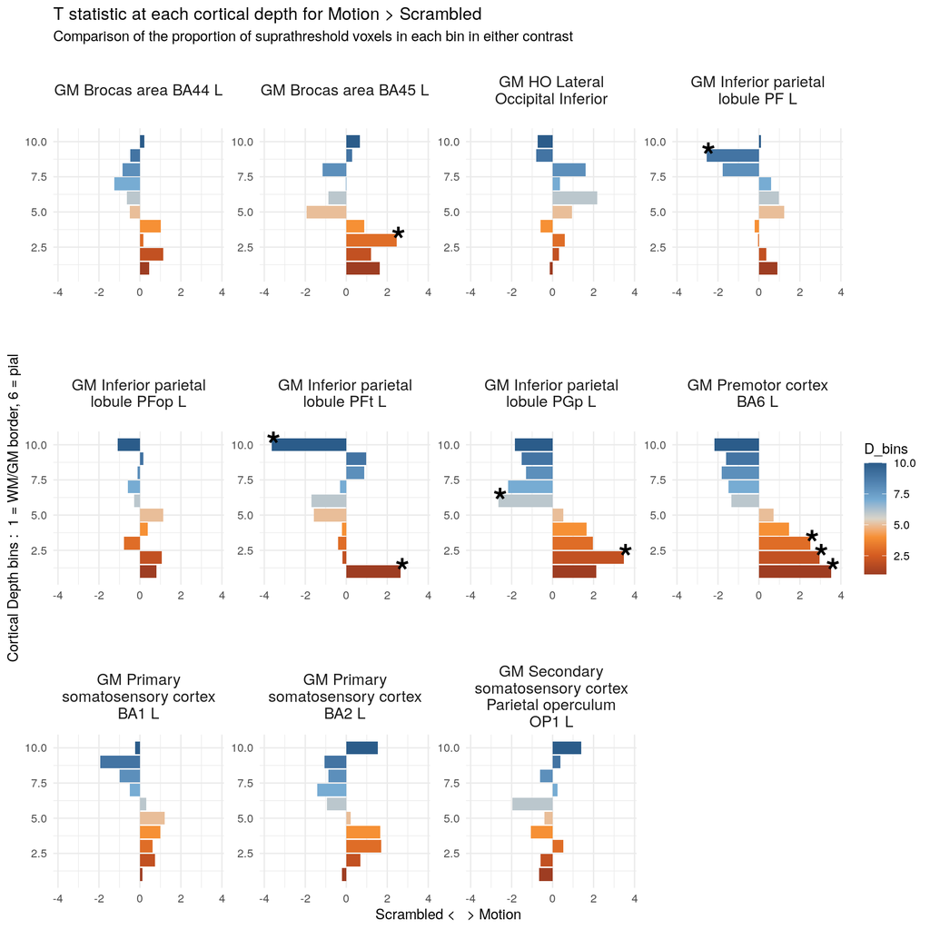

```r
# Plot the effect size (actually T stat) for the comparison Motion > Scrambled
res %>%
  mutate(D_bins = as.numeric(D_bins)) %>%
  ggplot( aes(x = D_bins, y = T, fill = D_bins ) ) +
  # scale_fill_gradient(low = "orange", high = "blue", na.value = NA) +
  scale_fill_gradient2_tableau() +
  geom_bar(stat = "identity", position = position_identity()) +
  geom_text( aes(x = pcorr_sig, y = T + 0.1, label = "*"), fontface = "bold", size=10, na.rm = T ) +
  facet_wrap(~ name, scales = "free", labeller = label_wrap_gen(width=22)) +
  # coord_cartesian(ylim = c(min(res$T), max(res$T) + 0.2)) +
  theme_minimal() +  # also theme_bw and theme_few
  labs(
    title = "T statistic at each cortical depth for Motion > Scrambled",
    subtitle = "Comparison of the proportion of suprathreshold voxels in each bin in either contrast"
  ) +
  ylab("Scrambled <   > Motion") + xlab("Cortical Depth bins :  1 = WM/GM border, 6 = pial")+
  theme(
    strip.text.x = element_text(size = 12), # increase size of title for each subplot
    panel.spacing.y = unit(3, "lines")      # increase space between facets
  ) +
  coord_flip(ylim = c(min(res$T) - 0.2, max(res$T) + 0.2))
```

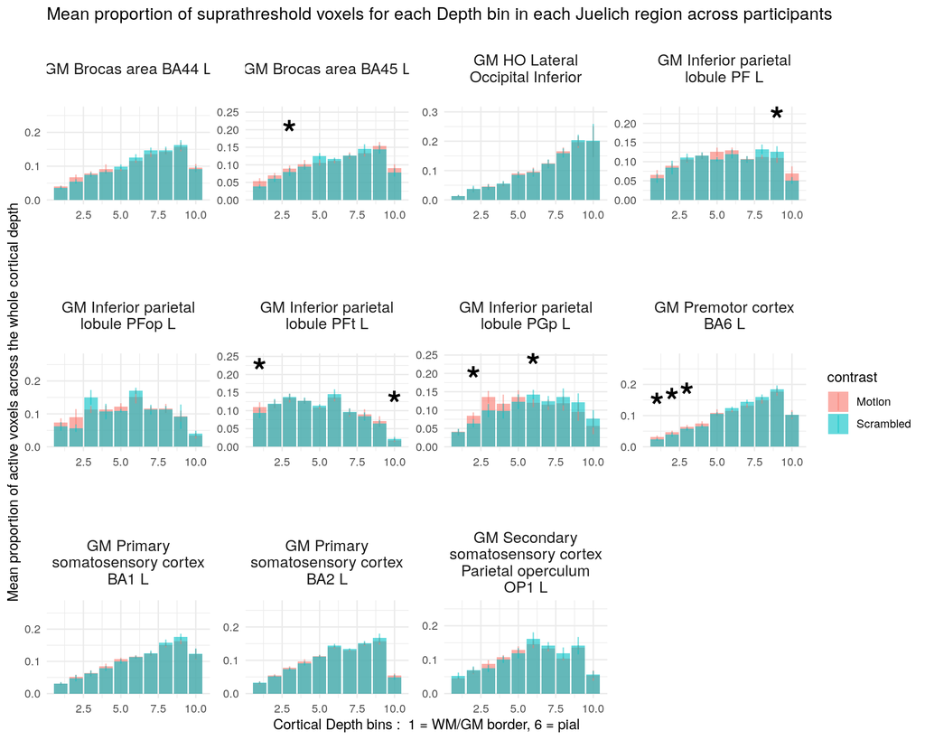

```r
# function to calculate standard error after removing NAs
sterr <- function(x) {
  x <- x[!is.na(x)]
  sd(x)/sqrt(length(x))
}

res_descriptives <- res %>%
  select(-c(T,p,pcorr)) %>%
  unnest(data) %>%
  gather(Motion, Scrambled, key = "contrast", value = "raw") %>%
  # filter(JU == 13, D_bins ==1) %>%  # to remove later
  group_by(JU, name, D_bins, contrast, pcorr_sig) %>%
  summarise(
    meanZ = mean(raw, na.rm = T),
    sterrZ = sterr(raw),
    .groups = "drop"
  )



res_descriptives %>%
  mutate(pcorr_sig = ifelse(contrast == "Motion", pcorr_sig, NA)) %>%  # to plot only one asterisk
  ggplot( aes(x = D_bins, y = meanZ, fill = contrast) ) +
  geom_bar(stat = "identity", position = position_identity(), alpha = 0.6) +
  geom_text(
    aes(x = pcorr_sig, y = meanZ + 0.1, label = "*"), fontface = "bold", size=10, na.rm = T
  ) +
  geom_linerange(aes(ymin = meanZ - sterrZ, ymax = meanZ + sterrZ, color=contrast), alpha = 0.5) +
  # coord_cartesian(ylim = c(zthr, max(res_descriptives$meanZ) + 0.2)) +
  facet_wrap(~ name, scales = "free", labeller = label_wrap_gen(width=22)) +
  theme_minimal() +
  labs(
    title = "Mean proportion of suprathreshold voxels for each Depth bin in each Juelich region across participants"
  ) +
  ylab("Mean proportion of active voxels across the whole cortical depth") + xlab("Cortical Depth bins :  1 = WM/GM border, 6 = pial") +
  theme(
    strip.text.x = element_text(size = 12), # increase size of title for each subplot
    panel.spacing.y = unit(3, "lines")      # increase space between facets
  )
```